# Final Thesis

```r
R_1 <- 0.8187
```

```r
model_2 <- train(Pop_growth ~ . + Continent*civil_rights + Continent*School_years - Continent - Life_expec_sq - civil_rights - educexp_schlyrs - Life_expec - lg_ratio_fm -lifexp_schlyrs - marriage_per_1000_sq - ratio_f_m_educ-ratio_fm_schlyrs, data = train_data,
                     preProc=c('scale','center'),
                     method='lm',
                     trControl=ctrl)
summary(model_2)
```

```
##
## Call:
## lm(formula = .outcome ~ ., data = dat)
##
## Residuals:
##     Min      1Q  Median      3Q     Max
## -3.5087 -0.2454  0.0026  0.2366  3.0283
##
## Coefficients:
##                                        Estimate Std. Error t value Pr(>|t|)
## (Intercept)                            1.562640   0.009939 157.228  < 2e-16 ***
## Gdppc_growth                          -0.126704   0.027877  -4.545 5.70e-06 ***
## School_years                          -0.138940   0.030394  -4.571 5.04e-06 ***
## Educ_expend                           -0.083670   0.020371  -4.107 4.11e-05 ***
## health_expdpc                          0.204613   0.022773   8.985  < 2e-16 ***
## net_migration_rate                     0.408272   0.011050  36.949  < 2e-16 ***
## Median_age                             0.280952   0.113544   2.474  0.01340 *
## marriage_per_1000                      0.014910   0.011814   1.262  0.20702
## relig_feel                             0.068801   0.016040   4.289 1.85e-05 ***
## tert_educ                              0.073502   0.014589   5.038 4.98e-07 ***
## lg_Median_age                         -1.576262   0.114621 -13.752  < 2e-16 ***
## lg_health_expdpc                       0.077651   0.027456   2.828  0.00471 **
## lg_Life_expec                          0.182550   0.022556   8.093 8.33e-16 ***
## lg_Educ_expend                         0.042295   0.020783   2.035  0.04193 *
## lg_Gdppc_growth                        0.075589   0.018334   4.123 3.84e-05 ***
## gdp_schlyrs                            0.037540   0.021480   1.748  0.08063 .
## `ContinentAfrica:civil_rights`        -0.045540   0.026389  -1.726  0.08450 .
## `ContinentAsia:civil_rights`          -0.029961   0.025538  -1.173  0.24082
## `ContinentEurope:civil_rights`        -0.095062   0.016927  -5.616 2.13e-08 ***
## `ContinentNorth America:civil_rights` -0.134549   0.018118  -7.426 1.44e-13 ***
## `ContinentOceania:civil_rights`        0.030024   0.111051   0.270  0.78690
## `ContinentSouth America:civil_rights` -0.040559   0.021283  -1.906  0.05678 .
## `ContinentAsia:School_years`           0.032174   0.031036   1.037  0.29996
## `ContinentEurope:School_years`         0.018499   0.042964   0.431  0.66680
## `ContinentNorth America:School_years`  0.055420   0.022634   2.449  0.01440 *
## `ContinentOceania:School_years`        0.006782   0.111448   0.061  0.95148
## `ContinentSouth America:School_years`  0.002309   0.025973   0.089  0.92917
## ---
## Signif. codes:  0 '***' 0.001 '**' 0.01 '*' 0.05 '.' 0.1 ' ' 1
##
## Residual standard error: 0.5504 on 3040 degrees of freedom
## Multiple R-squared:  0.8178, Adjusted R-squared:  0.8163
## F-statistic:   525 on 26 and 3040 DF,  p-value: < 2.2e-16
```

```r
R_2 <- 0.819
```

```r
model_3 <- train(Pop_growth ~ . + Continent*civil_rights + Continent*School_years - Continent - Life_expec_sq - civil_rights - educexp_schlyrs - Life_expec - lg_ratio_fm -lifexp_schlyrs - marriage_per_1000_sq - tert_educ, data = train_data,
                     preProc=c('scale','center'),
                     method='lm',
                     trControl=ctrl)
summary(model_3)
```

```
##
## Call:
## lm(formula = .outcome ~ ., data = dat)
##
## Residuals:
##     Min      1Q  Median      3Q     Max
## -3.4258 -0.2388  0.0041  0.2304  3.0563
##
## Coefficients:
##                                         Estimate Std. Error t value Pr(>|t|)
## (Intercept)                            1.5626397  0.0099109 157.669  < 2e-16
## Gdppc_growth                          -0.1097180  0.0277860  -3.949 8.04e-05
## School_years                          -0.3114713  0.0630991  -4.936 8.39e-07
## Educ_expend                           -0.0791538  0.0203281  -3.894 0.000101
## health_expdpc                          0.1989271  0.0227036   8.762  < 2e-16
## net_migration_rate                     0.4152404  0.0108946  38.114  < 2e-16
## Median_age                             0.2281885  0.1141309   1.999 0.045658
## marriage_per_1000                      0.0244482  0.0116369   2.101 0.035730
## relig_feel                             0.0706539  0.0160433   4.404 1.10e-05
## ratio_f_m_educ                        -0.2178048  0.0333731  -6.526 7.87e-11
## lg_Median_age                         -1.5092851  0.1156772 -13.047  < 2e-16
## lg_health_expdpc                       0.0957042  0.0278160   3.441 0.000588
## lg_Life_expec                          0.2371773  0.0224465  10.566  < 2e-16
## lg_Educ_expend                         0.0412206  0.0207834   1.983 0.047419
## lg_Gdppc_growth                        0.0752402  0.0182831   4.115 3.97e-05
## ratio_fm_schlyrs                       0.4396217  0.0890235   4.938 8.31e-07
## gdp_schlyrs                            0.0255979  0.0214096   1.196 0.231935
## `ContinentAfrica:civil_rights`        -0.0221193  0.0247740  -0.893 0.372012
## `ContinentAsia:civil_rights`           0.0272738  0.0233437   1.168 0.242754
## `ContinentEurope:civil_rights`        -0.0645033  0.0165323  -3.902 9.76e-05
## `ContinentNorth America:civil_rights` -0.1062723  0.0177665  -5.982 2.47e-09
## `ContinentOceania:civil_rights`        0.0250631  0.1107007   0.226 0.820903
## `ContinentSouth America:civil_rights` -0.0111184  0.0212291  -0.524 0.600501
## `ContinentAsia:School_years`          -0.0545921  0.0330609  -1.651 0.098789
## `ContinentEurope:School_years`        -0.1245482  0.0454945  -2.738 0.006224
## `ContinentNorth America:School_years` -0.0006802  0.0242424  -0.028 0.977617
## `ContinentOceania:School_years`       -0.0225768  0.1113405  -0.203 0.839326
## `ContinentSouth America:School_years` -0.0623439  0.0271458  -2.297 0.021708
##
## (Intercept)                           ***
```

[output cut: 18 more lines]

```
## `ContinentEurope:civil_rights`        ***
## `ContinentNorth America:civil_rights` ***
## `ContinentOceania:civil_rights`
## `ContinentSouth America:civil_rights`
## `ContinentAsia:School_years`          .
## `ContinentEurope:School_years`        **
## `ContinentNorth America:School_years`
## `ContinentOceania:School_years`
## `ContinentSouth America:School_years` *
## ---
## Signif. codes:  0 '***' 0.001 '**' 0.01 '*' 0.05 '.' 0.1 ' ' 1
##
## Residual standard error: 0.5489 on 3039 degrees of freedom
## Multiple R-squared:  0.8189, Adjusted R-squared:  0.8173
## F-statistic:   509 on 27 and 3039 DF,  p-value: < 2.2e-16
```

```r
R_3 <- 0.8202
```

```r
data.frame(R_1,R_2,R_3)
```

```
##      R_1   R_2    R_3
## 1 0.8187 0.819 0.8202
```

## Logistic Model

The output coefficients from our previous model are fitted into the generation of a single-weighted education attribute arguing for both the econometric omission of any potential confounders and the significance of each effect on population dynamics. We generate our target variable (positive or negative population growth rate) and the “education dimension” as our weighted average.

```r
data_logistic <- data %>%
  mutate(target = ifelse(Pop_growth > 0,0,1),
         education = 0.21*School_years + 0.08*Educ_expend +
           0.15*ratio_f_m_educ + 0.03*tert_educ + 0.03*gdp_schlyrs + 0.28*ratio_fm_schlyrs) %>%
  drop_na()
```

We relevel the target variable to calculate the probabilities in terms of the odds of incurring into negative growth rates:

```r
data_logistic <- data_logistic %>%
  mutate(target = as.factor(target),
         target = relevel(target, ref = "0"))
```

As usual, we split our logistic data into the training and testing set:

```r
set.seed(123)
training_samples <- data_logistic$target %>%
  createDataPartition(p = 0.6, list = FALSE)
train_data <- data_logistic %>%
  slice(training_samples)
test_data <- data_logistic %>%
  slice(-training_samples)
```

As an initial step, let´s plot the distribution of our education variable (which spans from 0 to less than 500) for our two groups of economies. These are, countries holding negative and positive growth rates in population. We notice the fact that economies which are experiencing negative growth rates are much more likely to have larger values of our education dimension:

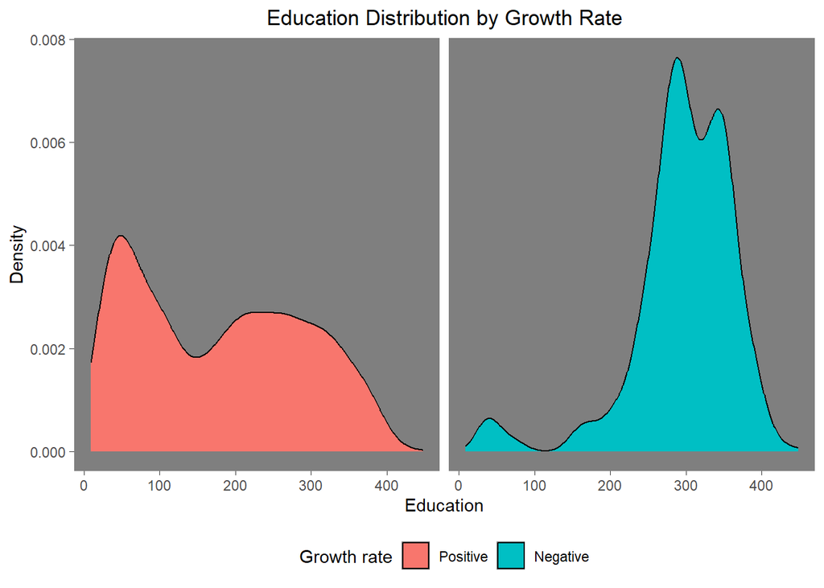

```r
data_logistic %>%
  ggplot()+
  aes(education, fill = target)+
  geom_density() +
  facet_grid(~target)+
  theme_dark()+
  theme(panel.grid = element_blank(),
        strip.text = element_blank(),
        legend.position = "bottom",
        plot.title = element_text(hjust = 0.5))+
  labs(title = "Education Distribution by Growth Rate",
       fill = "Growth rate",
       x = "Education",
       y = "Density")+
  scale_fill_discrete(labels=c('Positive', 'Negative'))
```

Since there is an imbalance issue in our data set such that most of our economies hold positive population growth rates, we will resort to the *upSample* function which will create synthetic values based on our observations in order to weight more the minority class and obtain more accurate results in our binary classification model.

```r
set.seed(123)
train_data <- upSample(train_data,train_data$target)
```

We train our model as a function of education and the continental dimension. The aim is to be able to understand how much we can predict in terms of population dynamics just by resorting to the education variable. Our hypothesis establishes that education is a sufficiently powerful indicator of population growth rate.

```r
logit <- glm(target ~  Continent + education, data = train_data, family = "binomial")

summary(logit)
```

```
##
## Call:
## glm(formula = target ~ Continent + education, family = "binomial",
##     data = train_data)
##
## Deviance Residuals:
##     Min       1Q   Median       3Q      Max
## -2.3367  -0.4973   0.2036   0.7292   2.7122
##
## Coefficients:
##                          Estimate Std. Error z value Pr(>|z|)
## (Intercept)            -3.635e+00  1.621e-01 -22.426  < 2e-16 ***
## ContinentAsia           1.065e+00  1.799e-01   5.919 3.24e-09 ***
## ContinentEurope         2.184e+00  1.817e-01  12.023  < 2e-16 ***
## ContinentNorth America -8.290e-01  2.655e-01  -3.123  0.00179 **
## ContinentOceania       -1.515e+01  2.881e+02  -0.053  0.95805
## ContinentSouth America -2.796e+00  6.047e-01  -4.623 3.78e-06 ***
## education               9.253e-03  5.425e-04  17.055  < 2e-16 ***
## ---
## Signif. codes:  0 '***' 0.001 '**' 0.01 '*' 0.05 '.' 0.1 ' ' 1
##
## (Dispersion parameter for binomial family taken to be 1)
##
##     Null deviance: 6396.4  on 4613  degrees of freedom
## Residual deviance: 4017.5  on 4607  degrees of freedom
## AIC: 4031.5
##
## Number of Fisher Scoring iterations: 14
```

Let´s plot the marginal effects of the model and obtain a different curve for each of our continents. We close our binary analysis by plotting the results of the marginal effect of our model as a function of our education aggregate and quantify these results by continent. This is, together with the results of the linear model and the hypothesis on the importance of gender parity, one of the most noteworthy findings from the study. One identifies not merely that the partial contribution of education to the likelihood of experiencing a negative population growth rate follows a concave functionality (with leveler marginal effects at the extremes), but additionally these results differ significantly across continents.

```r
gg.pred <- ggpredict(logit, terms = c("education","Continent"))
```

```
## Data were 'prettified'. Consider using `terms="education [all]"` to get
##   smooth plots.
```

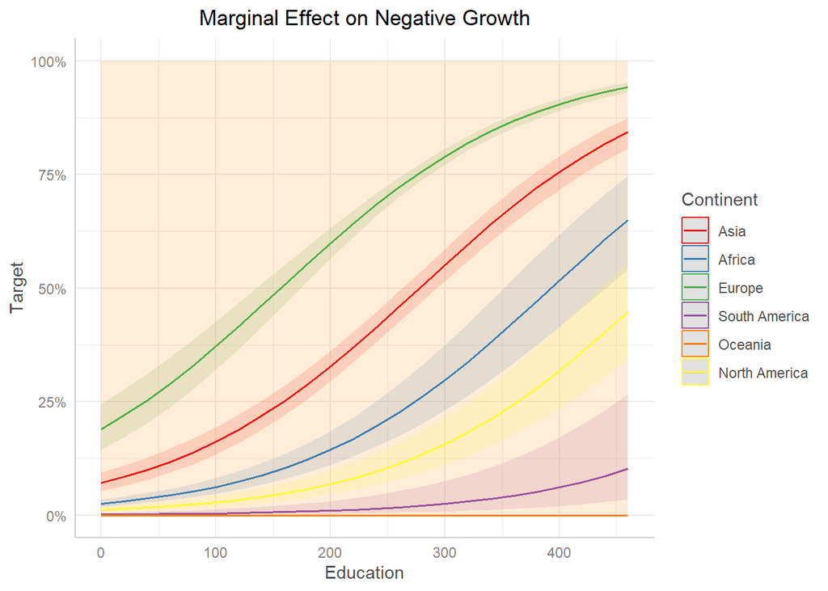

```r
plot(gg.pred)+
  geom_line()+
  labs(title = "Marginal Effect on Negative Growth",
       x = "Education", y = "Target")+
  theme(plot.title = element_text(hjust = 0.5))
```

For an “education level” of 300, the probability of an African region of holding negative growth rate is of 50 percentage points less than for Europe. This is, Europe and Asia are significantly more at risk than America or Oceania of experiencing these negative rates.

What does this look like in a classified confusion matrix? We will choose the threshold such that we will maximise the sensitivity, this is, the value which accounts for the correct classification of the minority class:

```r
probabilities <- logit %>%
  predict(test_data,type = "response")
predicted_cases <- ifelse(probabilities>0.5, "1", "0")
confusionMatrix(as.factor(predicted_cases), as.factor(test_data$target), positive = "1")
```

```
## Confusion Matrix and Statistics
##
##           Reference
## Prediction    0    1
##          0 1158   18
##          1  379  189
##
##                Accuracy : 0.7724
##                  95% CI : (0.7519, 0.7919)
##     No Information Rate : 0.8813
##     P-Value [Acc > NIR] : 1
##
##                   Kappa : 0.3798
##
##  Mcnemar's Test P-Value : <2e-16
##
##             Sensitivity : 0.9130
##             Specificity : 0.7534
##          Pos Pred Value : 0.3327
##          Neg Pred Value : 0.9847
##              Prevalence : 0.1187
##          Detection Rate : 0.1084
##    Detection Prevalence : 0.3257
##       Balanced Accuracy : 0.8332
##
##        'Positive' Class : 1
##
```

```r
roc <-roc(as.factor(test_data$target),probabilities)
```

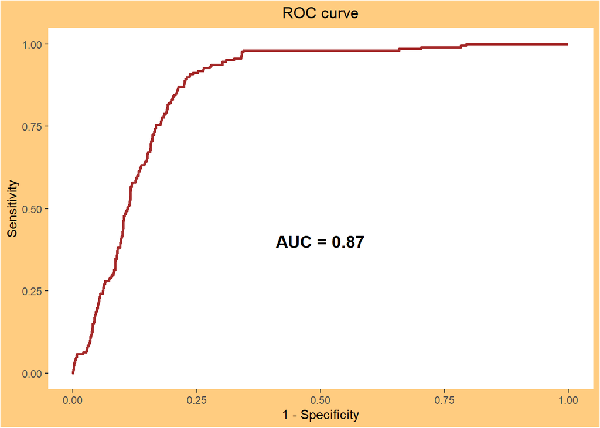

```r
sens <- roc$sensitivities
spec <- roc$specificities
ggplot(as.data.frame(sens,spec), aes(x = 1-spec,y = sens))+
  geom_line(color = "brown", size = 1)+
  annotate("text", x = 0.5, y = 0.4, label = paste0("AUC = ", round(auc(roc), 2)), size = 5, color = "black", fontface = "bold")+
  theme(panel.grid = element_blank(),
        plot.title = element_text(hjust = 0.5),
        plot.background = element_rect(fill = rgb(1,0.8,0.5)),panel.background = element_rect(fill = rgb(1,1,1)))+
  labs(title = "ROC curve", y = "Sensitivity", x = "1 - Specificity")
```

## Cluster Analysis

```r
data <- read.csv("final_data.csv")
```

By resorting to our education aggregate computed in the former segment as the exclusive input, we will separate our countries into 5 distinct clusters based on the unsupervised k-means algorithm which groups the observations by minimizing the Euclidian distance to each center. Acknowledging that one should ensure observations within a cluster are similar and variability between collections should be maximized, this process will be iterated several times and the resulting combination yielding the minimum variation will be selected.

```r
data_rec <- data %>%
  filter(Year > 2007) %>%
  mutate(target = ifelse(Pop_growth > 0,0,1),
         education = 0.21*School_years + 0.08*Educ_expend +
           0.15*ratio_f_m_educ + 0.03*tert_educ + 0.03*gdp_schlyrs + 0.28*ratio_fm_schlyrs) %>%
  dplyr::select(country_name,education)
head(data_rec)
```

```
##   country_name education
## 1        Aruba  324.5613
## 2        Aruba  367.7317
## 3        Aruba  336.3185
## 4        Aruba  189.4320
## 5        Aruba  400.3945
## 6        Aruba  306.5436
```

We generate our target variable and select the corresponding attributes required for such analysis:

```r
data <- data %>%
  mutate(target = ifelse(Pop_growth > 0,0,1),
         education = 0.21*School_years + 0.08*Educ_expend +
           0.15*ratio_f_m_educ + 0.03*tert_educ + 0.03*gdp_schlyrs + 0.28*ratio_fm_schlyrs) %>%
  dplyr::select(country_name,education)
head(data)
```

```
##   country_name education
## 1        Aruba        NA
## 2        Aruba        NA
## 3        Aruba        NA
## 4        Aruba        NA
## 5        Aruba        NA
## 6        Aruba        NA
```

We evaluate the mean education-aggregate obtained for each country for the given period in order to cluster and repeat the same analysis for the last 10 years of data to notice any relevant changes. This information is introduced in the appendix as a supplement to the core project:

```r
data_rec <- data_rec %>%
  group_by(country_name) %>%
  summarise(mean_educ = mean(education,na.rm = TRUE)) %>%
  drop_na()
names_rec <- data_rec$country_name
data_rec$country_name <- NULL
data_rec
```

```
## # A tibble: 258 × 1
##    mean_educ
##        <dbl>
##  1      37.7
##  2     194.
##  3     155.
##  4     271.
##  5     191.
##  6     253.
##  7     315.
##  8      95.9
##  9     299.
## 10     200.
## # … with 248 more rows
```

```r
data <- data %>%
  group_by(country_name) %>%
  summarise(mean_educ = mean(education,na.rm = TRUE)) %>%
  drop_na()
names <- data$country_name
data$country_name <- NULL
data
```

```
## # A tibble: 260 × 1
##    mean_educ
##        <dbl>
##  1      34.5
##  2     150.
##  3     155.
##  4     190.
##  5     129.
##  6     248.
##  7     268.
##  8      65.6
##  9     256.
## 10     159.
## # … with 250 more rows
```

```r
set.seed(123)
k <- 5
model_rec <- kmeans(data_rec, centers = k, nstart = 1000)
```

```r
set.seed(123)
k <- 5
model <- kmeans(data, centers = k, nstart = 1000)
```

```r
centers <- model$centers
centers
```

```
##   mean_educ
## 1 328.05420
## 2 262.21703
## 3 150.60601
## 4 204.43167
## 5  65.84147
```

```r
res_rec <- data.frame(names_rec,model_rec$cluster)
head(res_rec)
```

```
##                     names_rec model_rec.cluster
## 1                 Afghanistan                 5
## 2 Africa Eastern and Southern                 1
## 3  Africa Western and Central                 1
## 4                     Albania                 4
## 5                     Algeria                 1
## 6              American Samoa                 3
```

```r
res <- data.frame(names,model$cluster)
head(res)
```

```
##                         names model.cluster
## 1                 Afghanistan             5
## 2 Africa Eastern and Southern             3
## 3  Africa Western and Central             3
## 4                     Albania             4
## 5                     Algeria             3
## 6              American Samoa             2
```

We map the clustering results in which we can detect that southern European countries are grouped together with South American regions and Russia, pertaining to the second-best clan in terms of education. The strongest cluster encompasses Nordic economies, Australia, and North America whereas the least advanced one is occupied by most African economies in combination with India.

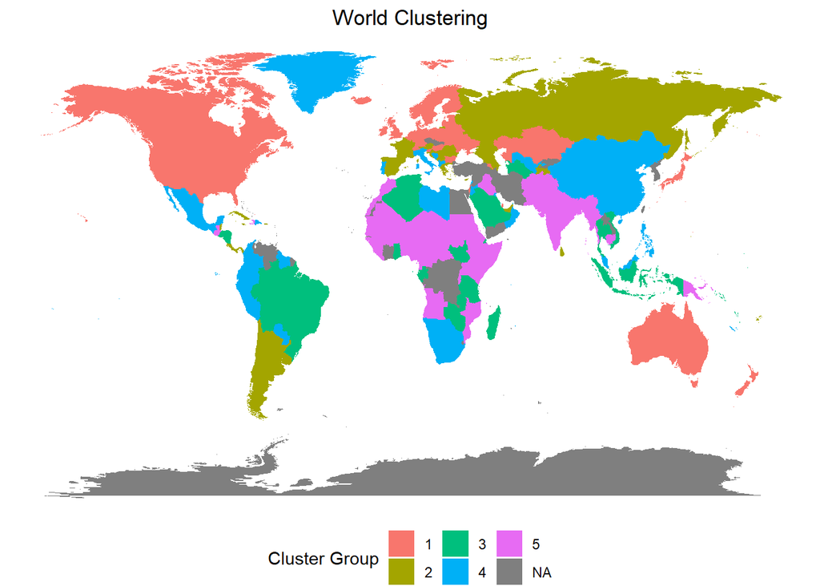

```r
res$names[res$names == "United States"] <- "USA"
res$names[res$names == "United Kingdom"] <- "UK"
res$names[res$names == "Russian Federation"] <- "Russia"
map <- map_data("world") %>%
  full_join(res, by =  c("region" = "names"))

map %>%
  ggplot(aes(long,lat))+
  geom_polygon(aes( group = group, fill = as.factor(model.cluster)))+
  theme_void()+
  theme(axis.title = element_blank(),
        legend.position = "bottom",
        plot.title = element_text(hjust = 0.5),
        panel.grid = element_blank())+
  labs(title = "World Clustering", fill = "Cluster Group")
```

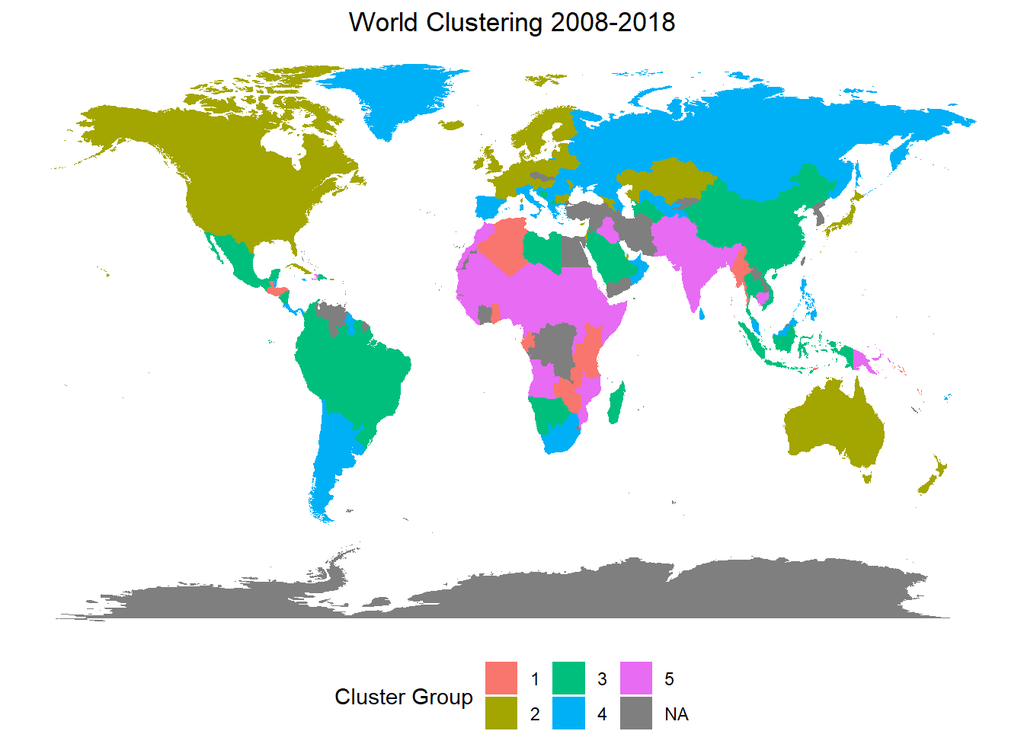

```r
res_rec$names[res_rec$names == "United States"] <- "USA"
res_rec$names[res_rec$names == "United Kingdom"] <- "UK"
res_rec$names[res_rec$names == "Russian Federation"] <- "Russia"
map <- map_data("world") %>%
  full_join(res_rec, by =  c("region" = "names"))

map %>%
  ggplot(aes(long,lat))+
  geom_polygon(aes( group = group, fill = as.factor(model_rec.cluster)))+
  theme_void()+
  theme(axis.title = element_blank(),
        legend.position = "bottom",
        plot.title = element_text(hjust = 0.5),
        panel.grid = element_blank())+
  labs(title = "World Clustering 2008-2018", fill = "Cluster Group")
```

```r
set.seed(1234)
sample <- res %>%
  group_by(model.cluster) %>%
  count() %>%
  dplyr::mutate(sample = list(sample(1:n,5,replace = FALSE))) %>%
  unnest() %>%
  dplyr::select(model.cluster, sample)
new_res <- res %>%
  arrange(desc(model.cluster)) %>%
  group_by(model.cluster) %>%
  mutate(id = 1:n()) %>%
  ungroup() %>%
  filter(!str_detect(names, "Income") & !str_detect(names, "Euro") & !str_detect(names, "income"), !str_detect(names, "countries"),!str_detect(names, "members"))

selection <- new_res %>%
  inner_join(sample, by = c("id" = "sample", "model.cluster"))
```

## Time series Modelling

```r
data <- read.csv("final_data.csv")
```

We reload the data and filter for the relevant time period. Next, we have to select the corresponding time and cluster attributes we will use for the time series analysis. We will have to pivot the data in order to pipe this information into ARIMA function supplied by R:

```r
time_series <- data %>%
  inner_join(selection, by = c("country_name" = "names")) %>%
  filter(Year > 1979, Year <2022) %>%
  dplyr::select(country_name,Year,model.cluster, Pop_growth)
```

```r
time_series <- time_series %>%
  group_by(Year,model.cluster) %>%
  mutate(growth = mean(Pop_growth)) %>%
  dplyr::select(Year,model.cluster,growth) %>%
  ungroup() %>%
  distinct()
```

Check stationarity! The appraisal of the set of Dickey fuller tests (unit root) to evaluate the premise of stationarity in mean can be resorted to by the user in the appendix in which the null hypothesis states that the coefficient of such autoregressive component behaves like a random walk.

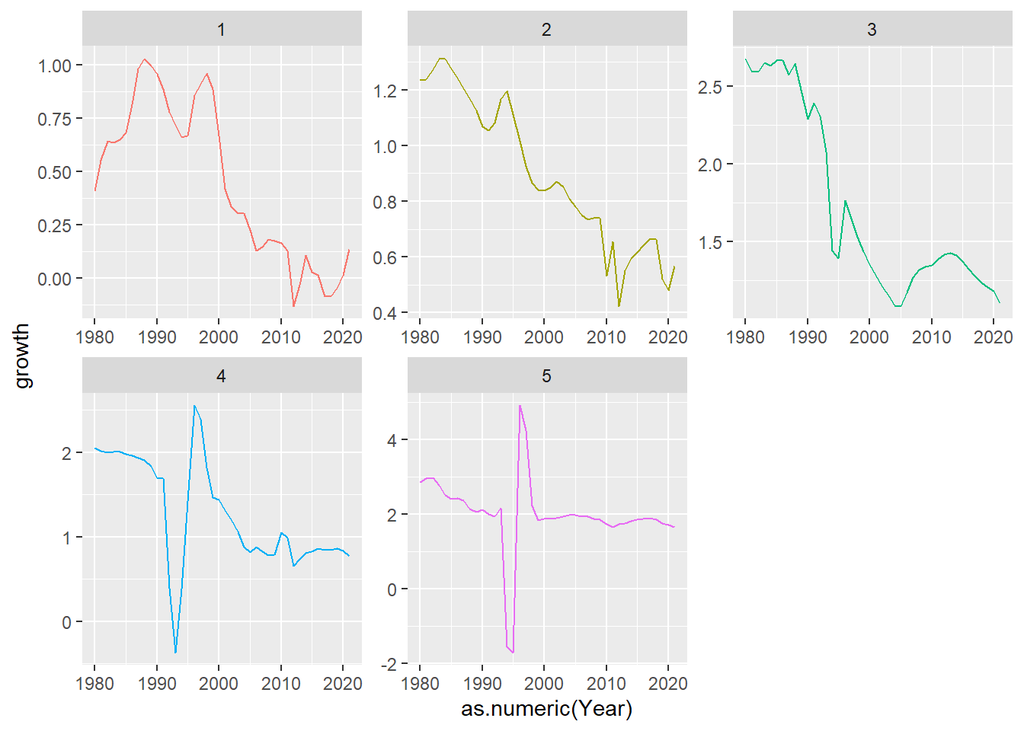

```r
time_series %>%
  ggplot()+
  aes(as.numeric(Year),growth, color = as.factor(model.cluster))+
  geom_line()+
  facet_wrap(~model.cluster, scales = "free")+
  theme(legend.position = "None")
```

The “AR” component will model the relationship between the current value of the temporal data and its past values and will assume that the latest observation of the series can be explained by a linear combination of its previous values. The “MA” element represents the association between the current measurement of the series and earlier shocks:

$$\dot{y}_t = c + \phi_1 \dot{y}_{t-1} + \phi_2 \dot{y}_{t-2} + \cdots + \theta_1 \varepsilon_t + \theta_2 \varepsilon_{t-1} + \cdots$$

```r
time_series <- time_series %>%
  pivot_wider(names_from = model.cluster, values_from = growth)
```

```r
adf.test(time_series$`1`)
```

```
##
##  Augmented Dickey-Fuller Test
##
## data:  time_series$`1`
## Dickey-Fuller = -2.7585, Lag order = 3, p-value = 0.2747
## alternative hypothesis: stationary
```

```r
adf.test(time_series$`2`)
```

```
##
##  Augmented Dickey-Fuller Test
##
## data:  time_series$`2`
## Dickey-Fuller = -3.302, Lag order = 3, p-value = 0.08499
## alternative hypothesis: stationary
```

```r
adf.test(time_series$`3`)
```

```
##
##  Augmented Dickey-Fuller Test
##
## data:  time_series$`3`
## Dickey-Fuller = -1.2474, Lag order = 3, p-value = 0.8703
## alternative hypothesis: stationary
```

```r
adf.test(time_series$`4`)
```

```
##
##  Augmented Dickey-Fuller Test
##
## data:  time_series$`4`
## Dickey-Fuller = -3.1206, Lag order = 3, p-value = 0.1319
## alternative hypothesis: stationary
```

```r
adf.test(time_series$`5`)
```

```
##
##  Augmented Dickey-Fuller Test
##
## data:  time_series$`5`
## Dickey-Fuller = -4.1379, Lag order = 3, p-value = 0.01376
## alternative hypothesis: stationary
```

```r
first_years <- time_series %>%
  filter(as.numeric(Year) <= 2019)

last_years <- time_series %>%
  filter(as.numeric(Year) >= 2019)
```

```r
model <- list()
for (i in 2:6) {
  new <- auto.arima(first_years[,i])
  model[[i-1]] <- new
}
```

```r
model
```

```
## [[1]]
## Series: first_years[, i]
## ARIMA(1,1,0) with drift
##
## Coefficients:
##           ar1    drift
##       -0.2733  -0.0177
## s.e.   0.1586   0.0087
##
## sigma^2 = 0.004939:  log likelihood = 49.2
## AIC=-92.41   AICc=-91.72   BIC=-87.42
##
## [[2]]
## Series: first_years[, i]
## ARIMA(0,1,1)
##
## Coefficients:
##          ma1
##       0.5601
## s.e.  0.1589
##
## sigma^2 = 0.00822:  log likelihood = 38.6
## AIC=-73.2   AICc=-72.87   BIC=-69.88
##
## [[3]]
## Series: first_years[, i]
## ARIMA(0,0,1) with non-zero mean
##
## Coefficients:
##          ma1    mean
##       0.8112  2.0235
## s.e.  0.0944  0.2463
##
## sigma^2 = 0.796:  log likelihood = -51.71
## AIC=109.41   AICc=110.08   BIC=114.48
##
## [[4]]
## Series: first_years[, i]
## ARIMA(2,1,0)
##
## Coefficients:
##          ar1      ar2
##       0.6363  -0.5041
## s.e.  0.1346   0.1308
##
## sigma^2 = 0.09581:  log likelihood = -8.97
## AIC=23.94   AICc=24.62   BIC=28.93
##
## [[5]]
## Series: first_years[, i]
## ARIMA(0,1,0) with drift
##
## Coefficients:
##         drift
##       -0.0377
## s.e.   0.0221
##
## sigma^2 = 0.01957:  log likelihood = 21.87
## AIC=-39.75   AICc=-39.41   BIC=-36.42
```

```r
cluster_1 <- data.frame(arima(first_years$`1`, order = c(2,0,0)) %>%
  forecast(h = 3))
cluster_2 <- arima(first_years$`2`, order = c(2,1,0))%>%
  forecast(h = 3) %>%
  data.frame()
cluster_3 <- arima(first_years$`3`, order = c(2,1,1)) %>%
  forecast(h = 3) %>%
  data.frame()
cluster_4 <- arima(first_years$`4`, order = c(0,0,1)) %>%
  forecast(h = 3) %>%
  data.frame()
cluster_5 <- arima(first_years$`5`, order = c(1,1,2))%>%
  forecast(h = 3) %>%
  data.frame()

results <- data.frame(last_years,cluster_1$Point.Forecast,
           cluster_2$Point.Forecast,
           cluster_3$Point.Forecast,
           cluster_4$Point.Forecast,
           cluster_5$Point.Forecast) %>%
  pivot_longer(-1, names_to = "Nature",values_to = "Value") %>% mutate(type = ifelse(str_detect(Nature,"cluster"),"Prediction","Original")) %>%
  mutate(Cluster = str_extract(Nature,"\\d")) %>%
  dplyr::select(Year,Cluster,type,Value)

results_2 <- data.frame(first_years) %>%
  pivot_longer(-1, names_to = "Nature",values_to = "Value") %>% mutate(cluster = str_remove(Nature,"X")) %>%
  mutate(Cluster = str_extract(Nature,"\\d")) %>%
  dplyr::select(Year,Cluster,Value)
```

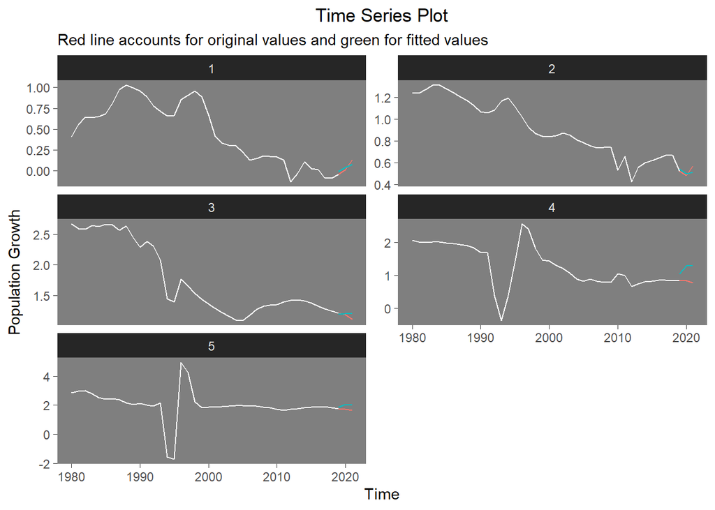

```r
results %>%
  ggplot()+
  aes(as.numeric(Year),Value, color = type)+
  geom_line()+
  facet_wrap(~Cluster, ncol = 2, scales = "free_y")+
  theme_dark()+
  theme(legend.position = "None",
        plot.title = element_text(hjust = 0.5),
        panel.grid = element_blank())+
  labs(title = "Time Series Plot",subtitle = "Red line accounts for original values and green for fitted values",
       y = "Population Growth", x = "Time")+
  geom_line(aes(as.numeric(Year),Value), data = results_2, color = "white")
```

Standard error of the model:

```r
 results %>%
  pivot_wider(names_from = type,values_from = Value) %>%
  mutate(sq_res = (Original-Prediction)^2,
         sd_err = (sum(sq_res)/15)^(1/2))
```

```
## # A tibble: 15 × 6
##     Year Cluster Original Prediction   sq_res sd_err
##    <int> <chr>      <dbl>      <dbl>    <dbl>  <dbl>
##  1  2019 2         0.521     0.541   0.000407  0.230
##  2  2019 1        -0.0445   -0.00234 0.00178   0.230
##  3  2019 5         1.75      1.88    0.0166    0.230
##  4  2019 4         0.860     1.04    0.0332    0.230
##  5  2019 3         1.21      1.19    0.000229  0.230
##  6  2020 2         0.482     0.495   0.000185  0.230
##  7  2020 1         0.0142    0.0384  0.000586  0.230
##  8  2020 5         1.71      2.04    0.109     0.230
##  9  2020 4         0.840     1.29    0.206     0.230
## 10  2020 3         1.18      1.20    0.000380  0.230
## 11  2021 2         0.568     0.508   0.00361   0.230
## 12  2021 1         0.138     0.0762  0.00384   0.230
## 13  2021 5         1.65      2.02    0.136     0.230
## 14  2021 4         0.775     1.29    0.269     0.230
## 15  2021 3         1.10      1.20    0.00966   0.230
```